##### **4.3 Model summary**

**Adjusted R-squared**: 0.1241 (below 0.6) - number of toilets (half) explains variance in the price in 12%.

**p-value**: 0.03436 (below, but very close to significance level = 0.05)

Residuals are not symmetrical.

```r
model_4a <- lm(data = dataset04, sale ~ half)
summary(model_4a)
```

```
##
## Call:
## lm(formula = sale ~ half, data = dataset04)
##
## Residuals:
##     Min      1Q  Median      3Q     Max
## -180.27  -75.27  -22.34   72.66  246.58
##
## Coefficients:
##             Estimate Std. Error t value Pr(>|t|)
## (Intercept)   228.27      28.78   7.932 1.59e-08 ***
## half           69.08      31.00   2.229   0.0344 *
## ---
## Signif. codes:  0 '***' 0.001 '**' 0.01 '*' 0.05 '.' 0.1 ' ' 1
##
## Residual standard error: 109.8 on 27 degrees of freedom
## Multiple R-squared:  0.1554, Adjusted R-squared:  0.1241
## F-statistic: 4.966 on 1 and 27 DF,  p-value: 0.03436
```

**Pearson’s correlation coefficient**: 0.394 (weak positive correlation)

```r
cor.test(data = dataset04, ~ sale + half)
```

```
##
##  Pearson's product-moment correlation
##
## data:  sale and half
## t = 2.2285, df = 27, p-value = 0.03436
## alternative hypothesis: true correlation is not equal to 0
## 95 percent confidence interval:
##  0.0323264 0.6646506
## sample estimates:
##       cor
## 0.3941621
```

**Residuals histogram**: not symmetrical (right skewed), residuals are not normally distributed

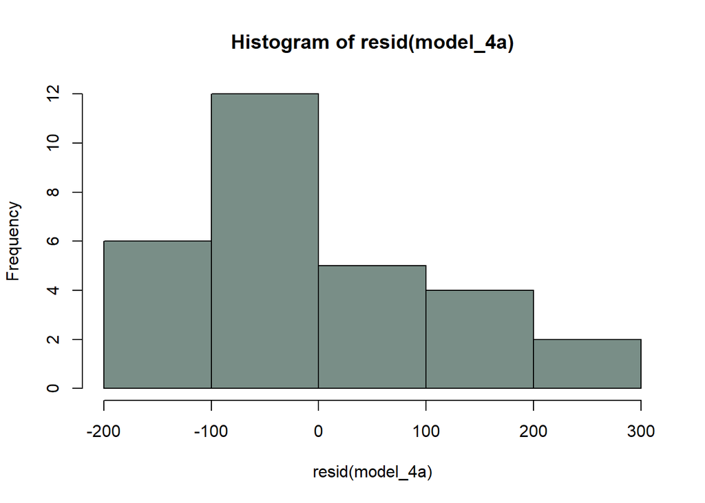

```r
hist(resid(model_4a), col = moon[1])
```

**Residuals vs fitted**: red line is parallel to center, points are symmetrically distributed

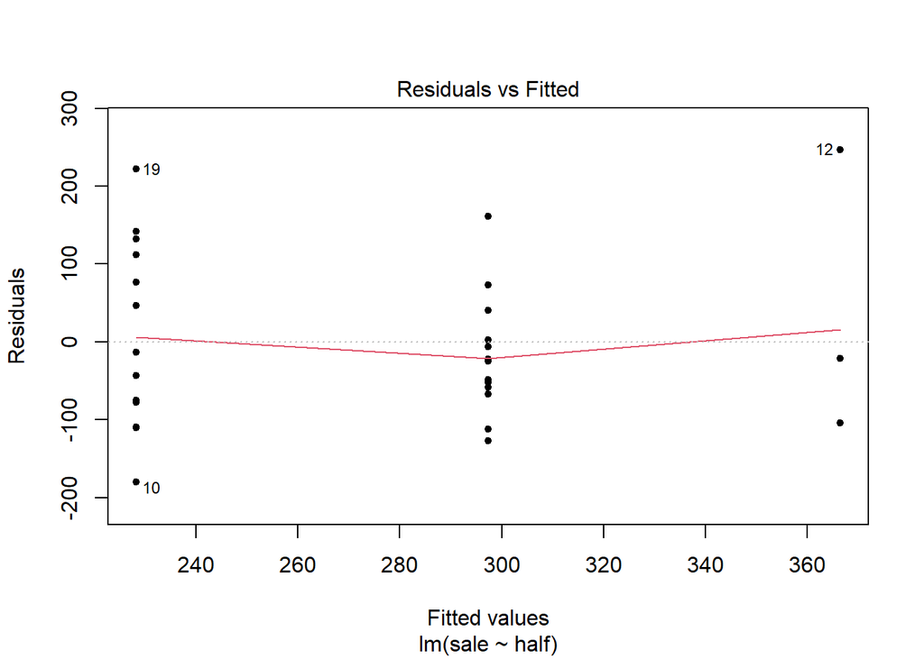

```r
plot(model_4a, 1, pch = 20)
```

**Normality**: points are rather symmetrically distributed

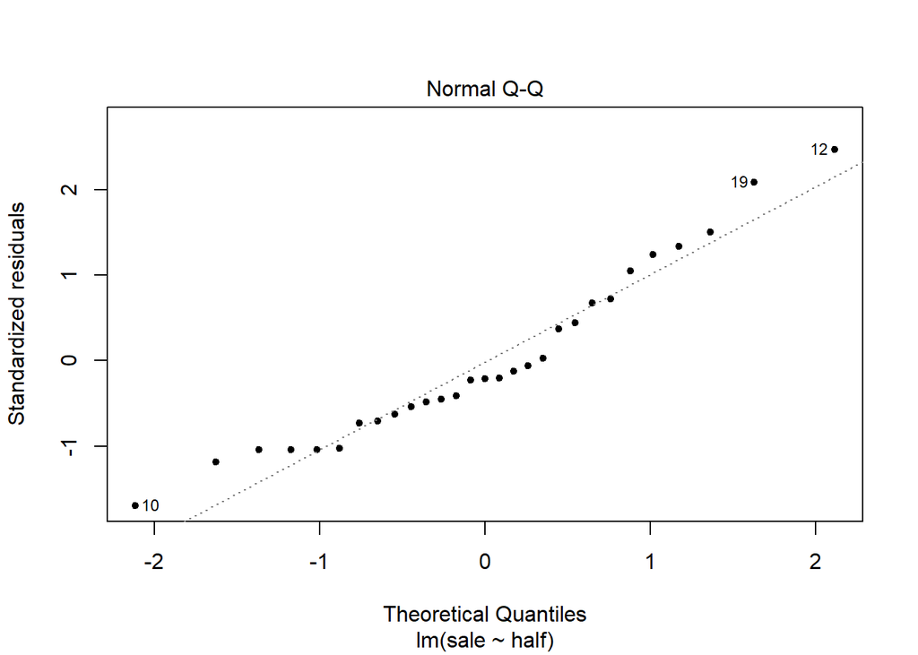

```r
plot(model_4a, 2, pch = 20)
```

**ANSWER**: assumptions of the model are not met (p value is very close to 0.05 and adjusted R-squared is below 0.6), also correlation between number of half-bathrooms and final house price is very weak (cor = 0.39). Possibly, other variables explain price difference better.

##### **4.4 Additional analysis**

We start with all variables (except listing price):

```r
model_4b <- lm(sale ~ .-list, data = dataset04)
summary(model_4b)
```

```
##
## Call:
## lm(formula = sale ~ . - list, data = dataset04)
##
## Residuals:
##    Min     1Q Median     3Q    Max
## -59.31 -34.06   7.20  21.32  55.93
##
## Coefficients:
##              Estimate Std. Error t value Pr(>|t|)
## (Intercept)  -135.263     37.283  -3.628  0.00141 **
## full           26.225     13.896   1.887  0.07181 .
## half           43.242     12.830   3.370  0.00264 **
## bedrooms       20.409     17.798   1.147  0.26329
## rooms           6.488     10.383   0.625  0.53823
## neighborhood   77.243     10.077   7.665 8.86e-08 ***
## ---
## Signif. codes:  0 '***' 0.001 '**' 0.01 '*' 0.05 '.' 0.1 ' ' 1
##
## Residual standard error: 39.29 on 23 degrees of freedom
## Multiple R-squared:  0.9079, Adjusted R-squared:  0.8879
## F-statistic: 45.34 on 5 and 23 DF,  p-value: 3.686e-11
```

**Adjusted R-squared**: 0.8879 (vs 0.1241 in model_4a)

**p-value**: 3.686e-11 (vs 0.03436 in model_4a)

Most influential variables are *neighborhood****, *half*** and in some part *full*. With significance level at 5% we should remove *rooms* and *bedrooms* from the model.

```r
# Model w/o listing price, rooms and bedrooms variables
model_4c <- lm(sale ~ full + half + neighborhood, data = dataset04)
summary(model_4c)
```

```
##
## Call:
## lm(formula = sale ~ full + half + neighborhood, data = dataset04)
##
## Residuals:
##     Min      1Q  Median      3Q     Max
## -90.448 -27.439  -2.208  26.630  90.323
##
## Coefficients:
##              Estimate Std. Error t value Pr(>|t|)
## (Intercept)    -56.47      26.69  -2.116 0.044474 *
## full            39.38      14.80   2.662 0.013396 *
## half            56.22      13.20   4.259 0.000254 ***
## neighborhood    77.77      11.03   7.053 2.16e-07 ***
## ---
## Signif. codes:  0 '***' 0.001 '**' 0.01 '*' 0.05 '.' 0.1 ' ' 1
##
## Residual standard error: 44.26 on 25 degrees of freedom
## Multiple R-squared:  0.8729, Adjusted R-squared:  0.8577
## F-statistic: 57.25 on 3 and 25 DF,  p-value: 2.436e-11
```

**Adjusted R-squared**: 0.8577 (vs 0.8879 in model_4b and 0.1241 in model_4a)

**p-value**: 2.436e-11 (vs 3.686e-11 in model_4b and 0.03436 in model_4a)

Comparison of models using Akaike and Bayesian information criterion: both methods choose model_4b (with all variables), although difference between 4b and 4c are not significant.

```r
AIC(model_4a,model_4b,model_4c)
```

```
##          df      AIC
## model_4a  3 358.7570
## model_4b  7 302.4971
## model_4c  5 307.8250
```

```r
BIC(model_4a,model_4b,model_4c)
```

```
##          df      BIC
## model_4a  3 362.8589
## model_4b  7 312.0682
## model_4c  5 314.6614
```

**SUMMARY:** The best model is model_4b (model with all variables, except listing price).

### **Exercise 05**

Match the classic model of population growth (logistic model: $y = \frac{a}{1 + e ^ {\frac{b-x}{c}}}$ with the USPop data from the carData package containing information about the US population from 1790 to 2000.

Draw a fitted regression function.

Are the assumptions of the model met?

##### **5.1 Check data set, assign to variable**

22 observations and 2 numeric variables (year and population), no missing values.

```r
# Libraries
library(carData)
library(nlstools)

# Summary statistic
skimr::skim(USPop)
```

Data summary

| Name | USPop |
| --- | --- |
| Number of rows | 22 |
| Number of columns | 2 |
| _______________________ |  |
| Column type frequency: |  |
| numeric | 2 |
| ________________________ |  |
| Group variables | None |

**Variable type: numeric**

| skim_variable | n_missing | complete_rate | mean | sd | p0 | p25 | p50 | p75 | p100 | hist |
| --- | --- | --- | --- | --- | --- | --- | --- | --- | --- | --- |
| year | 0 | 1 | 1895.00 | 64.94 | 1790.00 | 1842.5 | 1895.0 | 1947.50 | 2000.00 | ▇▆▆▆▇ |
| population | 0 | 1 | 94.68 | 87.26 | 3.93 | 18.6 | 69.6 | 146.54 | 281.42 | ▇▃▂▂▂ |

```r
# Assign data set to variable
dataset05 <- USPop
```

##### **5.2 Create models, main differences between linear and non-linear models**

```r
# Logistic model
model_5log <- nls(population ~ SSlogis(year, a, b, c), dataset05)
summary(model_5log)
```

```
##
## Formula: population ~ SSlogis(year, a, b, c)
##
## Parameters:
##   Estimate Std. Error t value Pr(>|t|)
## a  440.833     35.000   12.60 1.14e-10 ***
## b 1976.634      7.556  261.61  < 2e-16 ***
## c   46.284      2.157   21.45 8.87e-15 ***
## ---
## Signif. codes:  0 '***' 0.001 '**' 0.01 '*' 0.05 '.' 0.1 ' ' 1
##
## Residual standard error: 4.909 on 19 degrees of freedom
##
## Number of iterations to convergence: 0
## Achieved convergence tolerance: 6.818e-07
```

We have 3 parameters: a = 440.83, b = 1976.63, c = 46.28, all of them are relevant to the model (***).

19 degrees of freedom = number of observation (22) - the number of variables (3).

##### **5.3 Draw scatter plot**

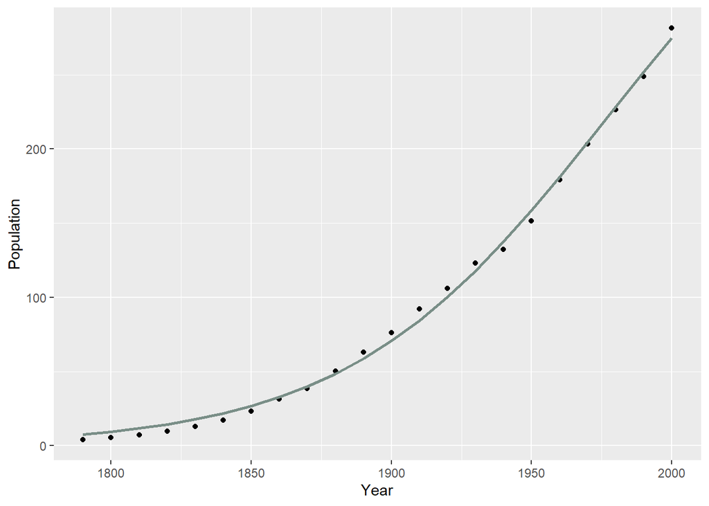

```r
ggplot(data = dataset05, aes(x = year, y = population)) +
  geom_point() +
  # Create regression line based on predictions using logistic model
  geom_line(y = predict(model_5log, dataset05$year), size = 1, color = moon[1]) +
  xlab('Year') + ylab('Population')
```

##### **5.4 Examine residual values to validate non-linear model assumptions**

Non-linear model assumptions are met if:

1. Residuals are normally distributed,
2. Residuals have the same variance,
3. Residuals are independent.

Residuals are not normally distributed:

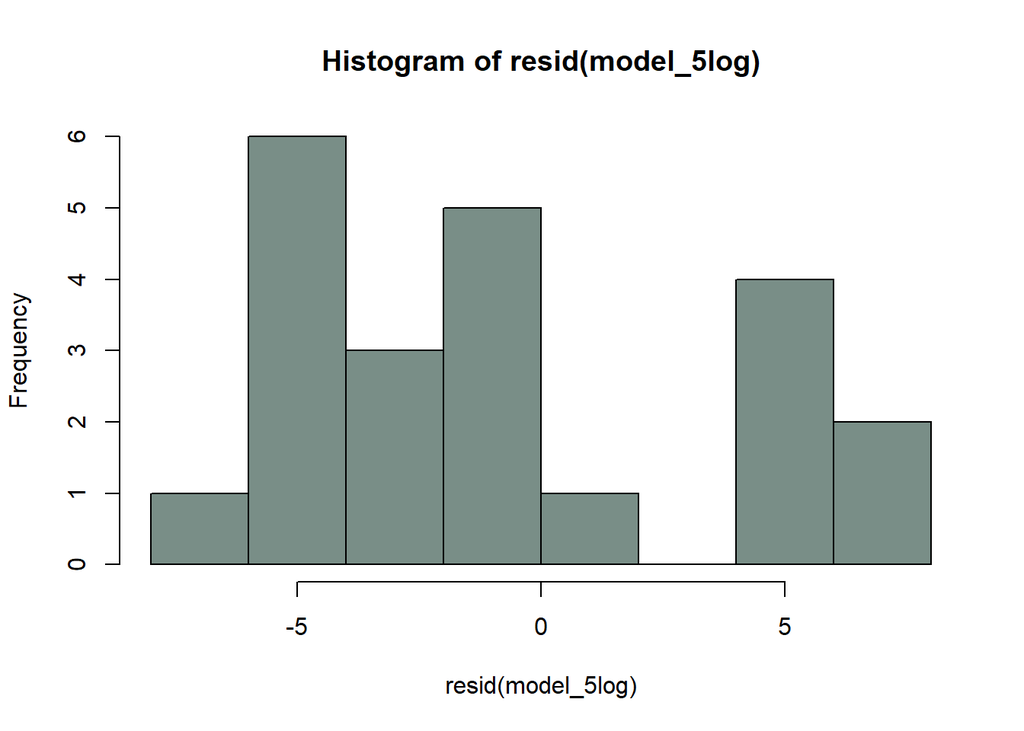

```r
hist(resid(model_5log), col = moon[1])
```

Variance is not homogeneous (points are not symmetrically distributed) and shows [positive correlation](https://www.originlab.com/doc/en/Origin-Help/Residual-Plot-Analysis):

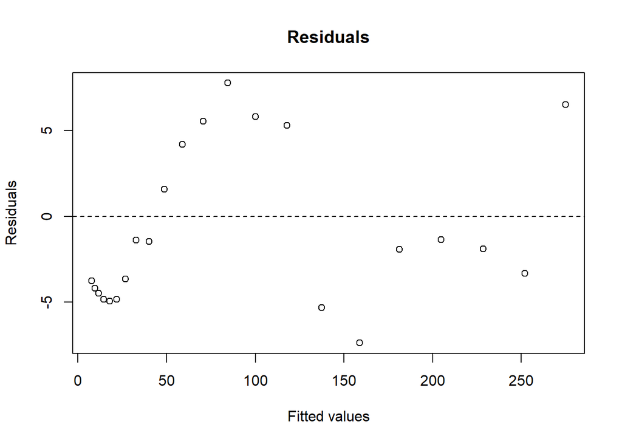

```r
plot(nlsResiduals(model_5log), 1)
```

**Shapiro-Wilk normality test**: if p-value is lower than 0.05 we can reject null hypothesis that residuals are normally distributed.

- **p-value = 0.01252** < 0.05, we reject null hypothesis, residuals are not normally distributed.

**The Runs Test**: low p-value (below 0.05) suggests that the residuals are not randomly distributed.

```r
test.nlsResiduals(nlsResiduals(model_5log))
```

```
##
## ------
##  Shapiro-Wilk normality test
##
## data:  stdres
## W = 0.88081, p-value = 0.01252
##
##
## ------
```

```
##
##  Runs Test
##
## data:  as.factor(run)
## Standard Normal = -3.3211, p-value = 0.0008966
## alternative hypothesis: two.sided
```

**SUMMARY**: Residuals indicates that assumptions of logistic model are not met (there is correlation between residuals and they are not normally distributed).

### **Exercise 06**

A skydiver jumps with a parachute from a hot air balloon.

Below are his velocities [m/s] in successive moments of time [s], starting from 1s.

Fit the Michaelis-Menten model to this data.

Draw a scatter plot with a fitted regression curve.

What speed the jumper will reach in the 17th second of the flight?

##### **6.1 Create data set**

```r
input <- ('t  v
          1  10
          2  16.3
          3  23
          4  27.5
          5  31
          6  35.6
          7  39
          8  41.5
          9  42.9
          10 45
          11 46
          12 45.5
          13 46
          14 49
          15 50')

dataset06 <- read.table(textConnection(input), header = TRUE)
```

##### **6.1 Create model**

```r
# Michaelis-Menten
model_6 <- nls(v ~ SSmicmen(t, a, b), dataset06)

summary(model_6)
```

```
##
## Formula: v ~ SSmicmen(t, a, b)
##
## Parameters:
##   Estimate Std. Error t value Pr(>|t|)
## a  70.1793     1.8887   37.16 1.39e-14 ***
## b   6.0109     0.3965   15.16 1.21e-09 ***
## ---
## Signif. codes:  0 '***' 0.001 '**' 0.01 '*' 0.05 '.' 0.1 ' ' 1
##
## Residual standard error: 1.057 on 13 degrees of freedom
##
## Number of iterations to convergence: 0
## Achieved convergence tolerance: 3.13e-07
```

##### **6.3 Draw scatter plot**

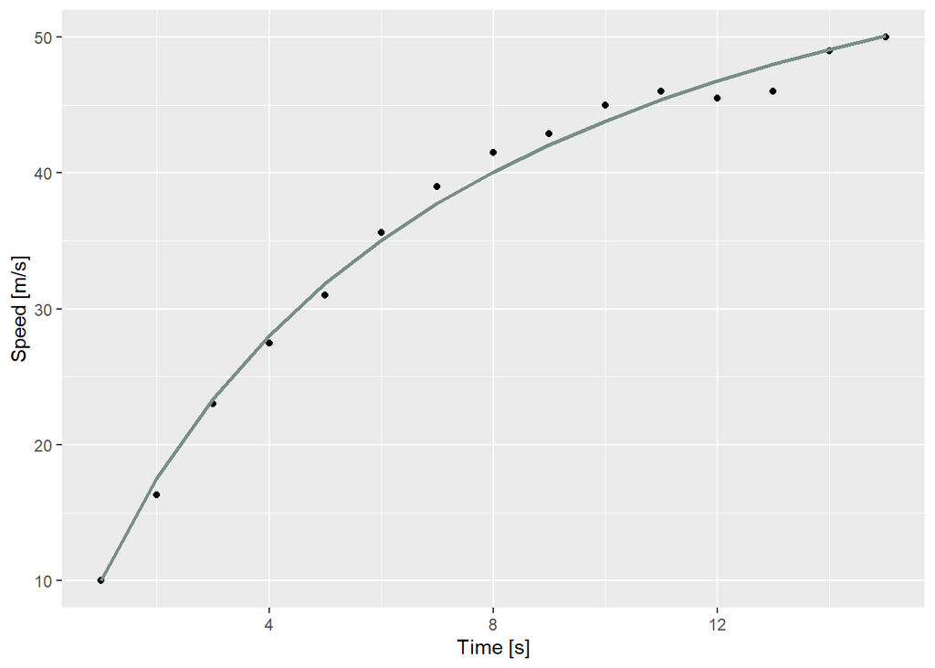

```r
ggplot(data = dataset06, aes(x = t, y = v)) +
  geom_point() +
  # Regression line based on predictions from Michaelis-Menten model
  geom_line(y = predict(model_6, dataset06$t), size = 1, color = moon[1]) +
  xlab('Time [s]') + ylab('Speed [m/s]')
```

##### **6.4 Speed prediction**

```r
(speed = predict(model_6, data.frame(t=17)))
```

```
## [1] 51.84704
## attr(,"gradient")
##              a         b
## [1,] 0.7387792 -2.253148
```

**SUMMARY**: In 17th second the diver will reach speed = 51.8470354 [m/s].

## **02. Data analysis - PCA**

### **Exercise 07**

Using the painters set (subjective assessments of painters) from the MASS package, perform a principal component analysis.

Investigate the loadings of the first three principal components.

Draw a scatter diagram for the first two principal components using different colors or symbols to distinguish schools of painting.

##### **7.1 Load libraries, assign palette, check & prepare data set**

1 factor (School), 4 numeric variables (Composition, Drawing, Color, Expression), no missing values.

```r
# Libraries
library(MASS)
library(plyr) # for mapvalues function

library(dplyr) # for ggbiplot
library(ggbiplot)
library(devtools)
install_github("vqv/ggbiplot")

# Create new palette (we need at least 8 colors to map all groups)
my_pal <- c(wes_palette('Moonrise2', n=4, type = 'discrete'),
          wes_palette('Cavalcanti1', n=2, type = 'discrete'),
          wes_palette('IsleofDogs1', n=2, type = 'discrete'))

skimr::skim(painters)
```

Data summary

| Name | painters |
| --- | --- |
| Number of rows | 54 |
| Number of columns | 5 |
| _______________________ |  |
| Column type frequency: |  |
| factor | 1 |
| numeric | 4 |
| ________________________ |  |
| Group variables | None |

**Variable type: factor**

| skim_variable | n_missing | complete_rate | ordered | n_unique | top_counts |
| --- | --- | --- | --- | --- | --- |
| School | 0 | 1 | FALSE | 8 | A: 10, D: 10, E: 7, G: 7 |

**Variable type: numeric**

| skim_variable | n_missing | complete_rate | mean | sd | p0 | p25 | p50 | p75 | p100 | hist |
| --- | --- | --- | --- | --- | --- | --- | --- | --- | --- | --- |
| Composition | 0 | 1 | 11.56 | 4.09 | 0 | 8.25 | 12.5 | 15.0 | 18 | ▁▃▆▆▇ |
| Drawing | 0 | 1 | 12.46 | 3.46 | 6 | 10.00 | 13.5 | 15.0 | 18 | ▅▅▃▇▅ |
| Colour | 0 | 1 | 10.94 | 4.65 | 0 | 7.25 | 10.0 | 16.0 | 18 | ▁▆▇▃▇ |
| Expression | 0 | 1 | 7.67 | 4.80 | 0 | 4.00 | 6.0 | 11.5 | 18 | ▃▇▃▃▂ |

```r
dataset07 <- painters
```

‘School’ is a qualitative variable, indicated by a factor level A-H. The school to which a painter belongs:

1. A: Renaissance
2. B: Mannerist
3. C: Seicento
4. D: Venetian
5. E: Lombard
6. F: Sixteenth Century
7. G: Seventeenth Century
8. H: French

```r
# Assign factor to new variable
school <- c(dataset07$School)

# Levels in "School' factor
levels(school)
```

```
## [1] "A" "B" "C" "D" "E" "F" "G" "H"
```

```r
# Re-assign level names for easier analysis later
school <- mapvalues(school,
          from = c('A', 'B', 'C', 'D', 'E', 'F', 'G', 'H'),
          to = c('Renaissance', 'Mannerist', 'Seicento', 'Venetian', 'Lombard', '16th Century', '17th Century', 'French'))

# Remove "school" variable from data set (PCA is done for quantitative variables only)
dataset07 <- dataset07[,-5]
```

##### **7.2 PCA analysis**

In our case, there is no need to scale the data (based on boxplot scale is unified.)

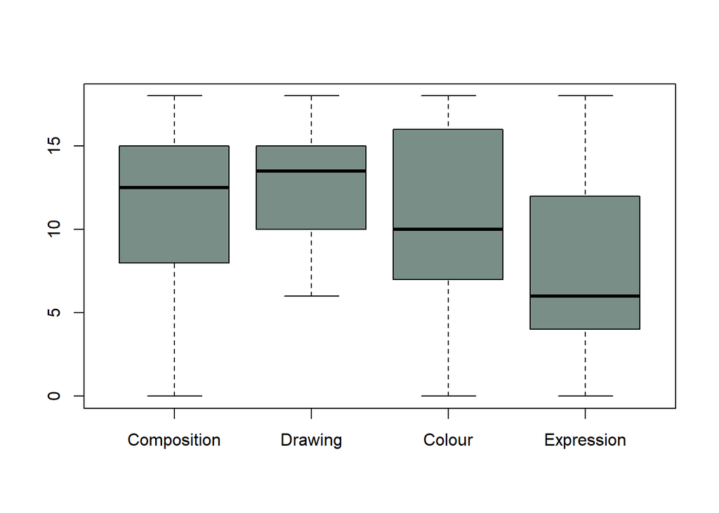

```r
boxplot(dataset07, col = moon[1])
```

PC1 explains 56% of total variance (*Proportion of Variance*), first 2 components explain in total 84,5% of total variance (*Cumulative Proportion*).

**Rotation** explains how each variable contributes to each principal component:

- To PC1 mostly contribute Expression (0.66), then in some part Composition (0.48),
- PC2 has strong negative weight for Colour (-0.84),
- PC3 has strong negative weight for Compostiion (-0.78) and positive weight of Expression (0.513)

```r
# PCA
dataset07_pca <- prcomp(dataset07)

# Summary
summary(dataset07_pca)
```

```
## Importance of components:
##                           PC1    PC2    PC3     PC4
## Standard deviation     6.4048 4.5733 2.5843 2.16743
## Proportion of Variance 0.5595 0.2853 0.0911 0.06408
## Cumulative Proportion  0.5595 0.8448 0.9359 1.00000
```

```r
dataset07_pca$rotation
```

```
##                    PC1        PC2        PC3        PC4
## Composition  0.4835097 -0.3764049 -0.7838341 -0.1007070
## Drawing      0.4240128  0.1871745  0.2796965 -0.8408024
## Colour      -0.3807729 -0.8452384  0.2108460 -0.3100452
## Expression   0.6644122 -0.3299350  0.5127553  0.4321821
```

##### **7.3 Biplot**

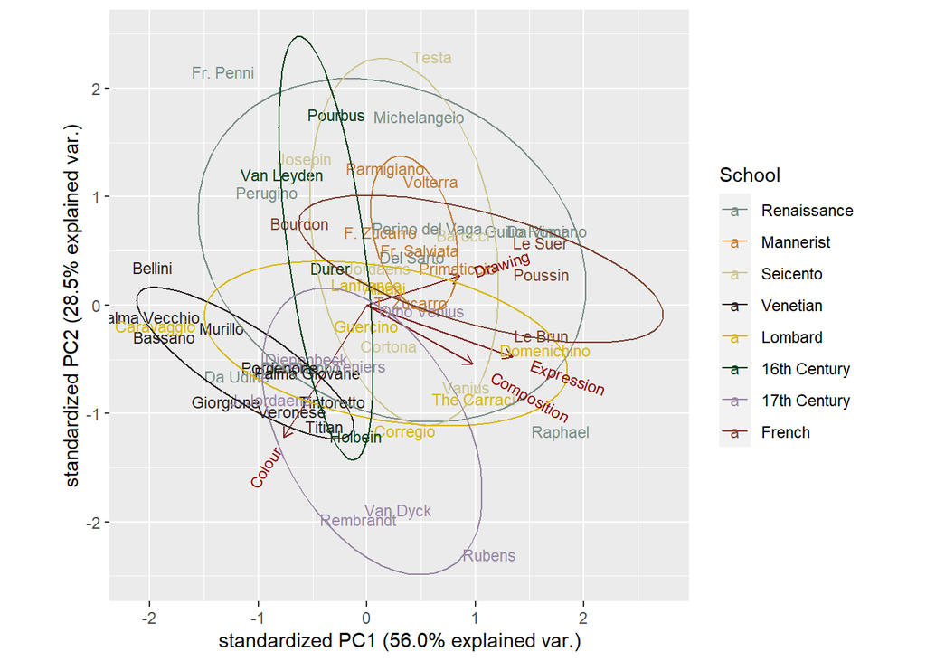

```r
ggbiplot(dataset07_pca, ellipse = TRUE, groups = school, labels = rownames(dataset07)) +
  scale_color_manual(name = 'School', values = c(my_pal))
```

**SUMMARY**: in terms of PCs, there is no correlation between Composition and Colour (angle close to 90 degrees). There is strong positive correlation between Composition and Expression (small angle). Colour and Drawing variables have negative correlation.

Painters assessment:

- Venetian painters were highly valued for Color, while on other characteristics they were received poorly (especially Drawing).
- Manerists were valued mostly for Drawing. Group is tightly clustered: there are small discrepancies between ratings they’ve received.
- Besides Bourdon, French painters were highly valued for Drawing, as well as Expression and Composition, all of them received rather low ratings for Colour.
- 16th Century Painters received rather low ratings in terms of Expression and Composition.
- High rated painters: Raphael, Rubens; low rated painters: Fr. Penni, Belini.

### **Exercise 08**

Using categorical and continuous variables from the Cars93 data set from the MASS package, perform principal component analysis.

Compare (in separate charts):

- American and other cars (Origin),
- Car types (Type).

##### **8.1 Check & prepare data set**

9 factor variables, 18 numeric. 93 rows of data. Missing values in columns: Rear.seat.room and Luggage.room

```r
skimr::skim(Cars93)
```

Data summary

| Name | Cars93 |
| --- | --- |
| Number of rows | 93 |
| Number of columns | 27 |
| _______________________ |  |
| Column type frequency: |  |
| factor | 9 |
| numeric | 18 |
| ________________________ |  |
| Group variables | None |

**Variable type: factor**

| skim_variable | n_missing | complete_rate | ordered | n_unique | top_counts |
| --- | --- | --- | --- | --- | --- |
| Manufacturer | 0 | 1 | FALSE | 32 | Che: 8, For: 8, Dod: 6, Maz: 5 |
| Model | 0 | 1 | FALSE | 93 | 100: 1, 190: 1, 240: 1, 300: 1 |
| Type | 0 | 1 | FALSE | 6 | Mid: 22, Sma: 21, Com: 16, Spo: 14 |
| AirBags | 0 | 1 | FALSE | 3 | Dri: 43, Non: 34, Dri: 16 |
| DriveTrain | 0 | 1 | FALSE | 3 | Fro: 67, Rea: 16, 4WD: 10 |
| Cylinders | 0 | 1 | FALSE | 6 | 4: 49, 6: 31, 8: 7, 3: 3 |
| Man.trans.avail | 0 | 1 | FALSE | 2 | Yes: 61, No: 32 |
| Origin | 0 | 1 | FALSE | 2 | USA: 48, non: 45 |
| Make | 0 | 1 | FALSE | 93 | Acu: 1, Acu: 1, Aud: 1, Aud: 1 |

**Variable type: numeric**

| skim_variable | n_missing | complete_rate | mean | sd | p0 | p25 | p50 | p75 | p100 | hist |
| --- | --- | --- | --- | --- | --- | --- | --- | --- | --- | --- |
| Min.Price | 0 | 1.00 | 17.13 | 8.75 | 6.7 | 10.8 | 14.7 | 20.3 | 45.4 | ▇▅▂▂▁ |
| Price | 0 | 1.00 | 19.51 | 9.66 | 7.4 | 12.2 | 17.7 | 23.3 | 61.9 | ▇▅▂▁▁ |
| Max.Price | 0 | 1.00 | 21.90 | 11.03 | 7.9 | 14.7 | 19.6 | 25.3 | 80.0 | ▇▃▁▁▁ |
| MPG.city | 0 | 1.00 | 22.37 | 5.62 | 15.0 | 18.0 | 21.0 | 25.0 | 46.0 | ▇▅▂▁▁ |
| MPG.highway | 0 | 1.00 | 29.09 | 5.33 | 20.0 | 26.0 | 28.0 | 31.0 | 50.0 | ▇▇▃▁▁ |
| EngineSize | 0 | 1.00 | 2.67 | 1.04 | 1.0 | 1.8 | 2.4 | 3.3 | 5.7 | ▆▇▇▁▁ |
| Horsepower | 0 | 1.00 | 143.83 | 52.37 | 55.0 | 103.0 | 140.0 | 170.0 | 300.0 | ▆▇▇▁▁ |
| RPM | 0 | 1.00 | 5280.65 | 596.73 | 3800.0 | 4800.0 | 5200.0 | 5750.0 | 6500.0 | ▂▆▇▇▆ |
| Rev.per.mile | 0 | 1.00 | 2332.20 | 496.51 | 1320.0 | 1985.0 | 2340.0 | 2565.0 | 3755.0 | ▃▅▇▂▁ |
| Fuel.tank.capacity | 0 | 1.00 | 16.66 | 3.28 | 9.2 | 14.5 | 16.4 | 18.8 | 27.0 | ▂▇▆▃▁ |
| Passengers | 0 | 1.00 | 5.09 | 1.04 | 2.0 | 4.0 | 5.0 | 6.0 | 8.0 | ▁▅▇▃▂ |
| Length | 0 | 1.00 | 183.20 | 14.60 | 141.0 | 174.0 | 183.0 | 192.0 | 219.0 | ▁▃▇▆▂ |
| Wheelbase | 0 | 1.00 | 103.95 | 6.82 | 90.0 | 98.0 | 103.0 | 110.0 | 119.0 | ▂▇▇▆▂ |
| Width | 0 | 1.00 | 69.38 | 3.78 | 60.0 | 67.0 | 69.0 | 72.0 | 78.0 | ▂▇▇▇▂ |
| Turn.circle | 0 | 1.00 | 38.96 | 3.22 | 32.0 | 37.0 | 39.0 | 41.0 | 45.0 | ▃▆▆▇▃ |
| Rear.seat.room | 2 | 0.98 | 27.83 | 2.99 | 19.0 | 26.0 | 27.5 | 30.0 | 36.0 | ▁▂▇▅▁ |
| Luggage.room | 11 | 0.88 | 13.89 | 3.00 | 6.0 | 12.0 | 14.0 | 15.0 | 22.0 | ▁▅▇▃▁ |
| Weight | 0 | 1.00 | 3072.90 | 589.90 | 1695.0 | 2620.0 | 3040.0 | 3525.0 | 4105.0 | ▂▆▇▇▆ |

```r
dataset08 <- Cars93
```

Data set preparation:

```r
# Exclude missing values
dataset08 <- na.omit(dataset08)

# Take 2 groups in which we will compare data later
origin <- c(dataset08$Origin)
type <- c(dataset08$Type)

# For labels on chart
make <- c(dataset08$Make)


# Transform some factor variables into numbers
# (we won't use labels used to analyze data, like Manufacturer & Model, Type, Origin and Make)

# Remove "label" columns from data set
lbls <- c('Manufacturer','Model','Type','Origin','Make')
dataset08[,lbls] <- list(NULL)

# Change factor columns to numeric
for (i in 1:ncol(dataset08)){
  if(sapply(dataset08[i], class) == 'factor'){
    dataset08[i] <- lapply(dataset08[i], function(x) as.integer(x))
    }
  }
```

After preparation we have 22 numeric columns and no missing values:

```r
skimr::skim(dataset08)
```

Data summary

| Name | dataset08 |
| --- | --- |
| Number of rows | 82 |
| Number of columns | 22 |
| _______________________ |  |
| Column type frequency: |  |
| numeric | 22 |
| ________________________ |  |
| Group variables | None |

**Variable type: numeric**

| skim_variable | n_missing | complete_rate | mean | sd | p0 | p25 | p50 | p75 | p100 | hist |
| --- | --- | --- | --- | --- | --- | --- | --- | --- | --- | --- |
| Min.Price | 0 | 1 | 16.83 | 8.92 | 6.7 | 9.65 | 14.20 | 20.82 | 45.4 | ▇▃▂▁▁ |
| Price | 0 | 1 | 19.17 | 9.96 | 7.4 | 11.65 | 16.10 | 23.60 | 61.9 | ▇▅▂▁▁ |
| Max.Price | 0 | 1 | 21.52 | 11.45 | 7.9 | 13.62 | 18.55 | 24.87 | 80.0 | ▇▃▁▁▁ |
| MPG.city | 0 | 1 | 23.09 | 5.59 | 16.0 | 19.00 | 22.00 | 25.00 | 46.0 | ▇▅▂▁▁ |
| MPG.highway | 0 | 1 | 29.98 | 5.01 | 22.0 | 26.00 | 29.00 | 32.75 | 50.0 | ▆▇▂▁▁ |
| AirBags | 0 | 1 | 2.15 | 0.72 | 1.0 | 2.00 | 2.00 | 3.00 | 3.0 | ▃▁▇▁▆ |
| DriveTrain | 0 | 1 | 2.11 | 0.47 | 1.0 | 2.00 | 2.00 | 2.00 | 3.0 | ▁▁▇▁▂ |
| Cylinders | 0 | 1 | 2.78 | 1.13 | 1.0 | 2.00 | 2.00 | 4.00 | 5.0 | ▁▇▁▃▁ |
| EngineSize | 0 | 1 | 2.59 | 1.00 | 1.0 | 1.80 | 2.30 | 3.20 | 5.7 | ▆▇▆▁▁ |
| Horsepower | 0 | 1 | 139.95 | 51.06 | 55.0 | 100.00 | 134.50 | 170.00 | 300.0 | ▇▇▇▂▁ |
| RPM | 0 | 1 | 5328.05 | 583.74 | 3800.0 | 5000.00 | 5400.00 | 5800.00 | 6500.0 | ▂▅▇▇▆ |
| Rev.per.mile | 0 | 1 | 2367.87 | 497.28 | 1320.0 | 2056.25 | 2380.00 | 2595.00 | 3755.0 | ▂▃▇▂▁ |
| Man.trans.avail | 0 | 1 | 1.68 | 0.47 | 1.0 | 1.00 | 2.00 | 2.00 | 2.0 | ▃▁▁▁▇ |
| Fuel.tank.capacity | 0 | 1 | 16.11 | 3.01 | 9.2 | 13.77 | 15.95 | 18.00 | 23.0 | ▂▅▇▆▂ |
| Passengers | 0 | 1 | 4.94 | 0.71 | 4.0 | 4.00 | 5.00 | 5.00 | 6.0 | ▅▁▇▁▃ |
| Length | 0 | 1 | 183.16 | 15.27 | 141.0 | 174.00 | 182.50 | 192.75 | 219.0 | ▁▃▇▆▂ |
| Wheelbase | 0 | 1 | 103.21 | 6.47 | 90.0 | 98.00 | 103.00 | 107.75 | 117.0 | ▂▅▇▃▂ |
| Width | 0 | 1 | 68.90 | 3.69 | 60.0 | 67.00 | 68.00 | 71.00 | 78.0 | ▂▇▆▅▂ |
| Turn.circle | 0 | 1 | 38.62 | 3.16 | 32.0 | 36.00 | 39.00 | 41.00 | 45.0 | ▃▇▆▇▃ |
| Rear.seat.room | 0 | 1 | 27.54 | 2.84 | 19.0 | 26.00 | 27.50 | 29.50 | 36.0 | ▁▃▇▃▁ |
| Luggage.room | 0 | 1 | 13.89 | 3.00 | 6.0 | 12.00 | 14.00 | 15.00 | 22.0 | ▁▅▇▃▁ |
| Weight | 0 | 1 | 2988.17 | 565.94 | 1695.0 | 2533.75 | 2970.00 | 3485.00 | 4105.0 | ▂▆▇▇▃ |

##### **8.2 PCA analysis**

There is high discrepancy in scale of variables, we need to normalize data.

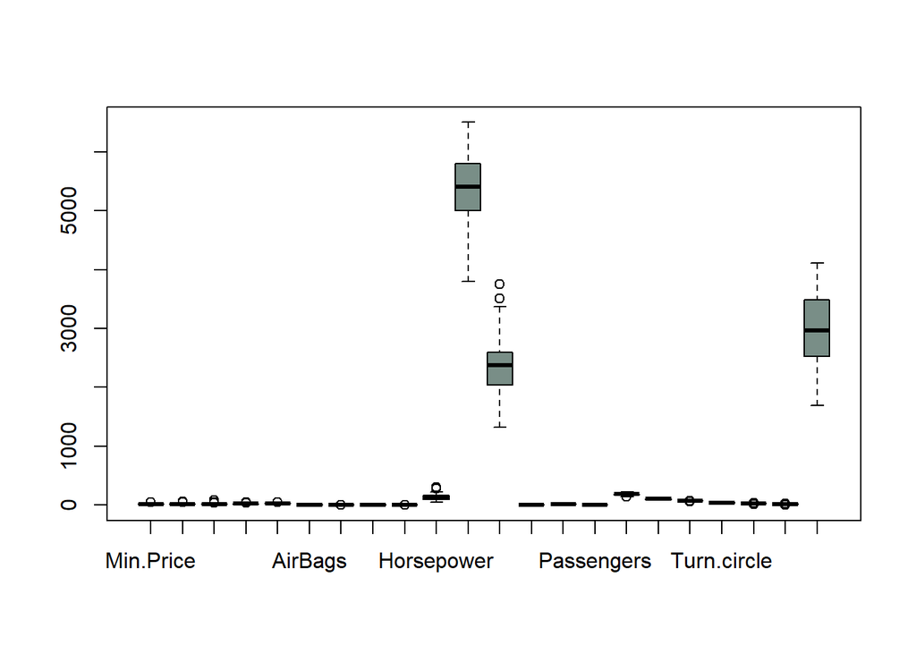

```r
boxplot(dataset08, col = moon[1])
```

```r
dataset08_pca <- prcomp(dataset08, scale. = TRUE)
summary(dataset08_pca)
```

```
## Importance of components:
##                           PC1    PC2    PC3     PC4     PC5     PC6     PC7
## Standard deviation     3.6414 1.5843 1.1208 1.00472 0.85690 0.76329 0.74189
## Proportion of Variance 0.6027 0.1141 0.0571 0.04588 0.03338 0.02648 0.02502
## Cumulative Proportion  0.6027 0.7168 0.7739 0.81979 0.85316 0.87965 0.90466
##                            PC8     PC9    PC10    PC11    PC12    PC13   PC14
## Standard deviation     0.66175 0.57955 0.52752 0.47389 0.44722 0.38275 0.3603
## Proportion of Variance 0.01991 0.01527 0.01265 0.01021 0.00909 0.00666 0.0059
## Cumulative Proportion  0.92457 0.93984 0.95249 0.96269 0.97178 0.97844 0.9843
##                           PC15    PC16    PC17    PC18    PC19    PC20    PC21
## Standard deviation     0.29217 0.26021 0.23185 0.22647 0.19422 0.17211 0.13760
## Proportion of Variance 0.00388 0.00308 0.00244 0.00233 0.00171 0.00135 0.00086
## Cumulative Proportion  0.98823 0.99130 0.99375 0.99608 0.99779 0.99914 1.00000
##                            PC22
## Standard deviation     0.001851
## Proportion of Variance 0.000000
## Cumulative Proportion  1.000000
```

##### **8.3 Biplots**

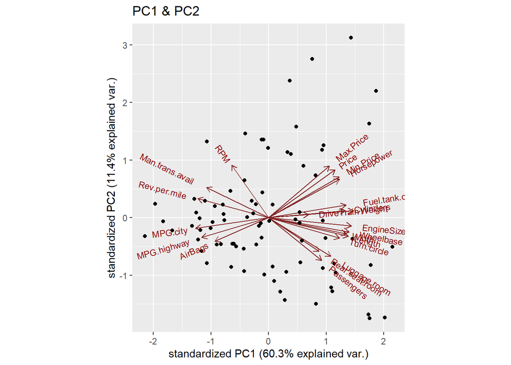

```r
# Biplot on PC1/PC2 grid
ggbiplot(dataset08_pca, choices = c(1,2)) +
  ggtitle('PC1 & PC2')
```

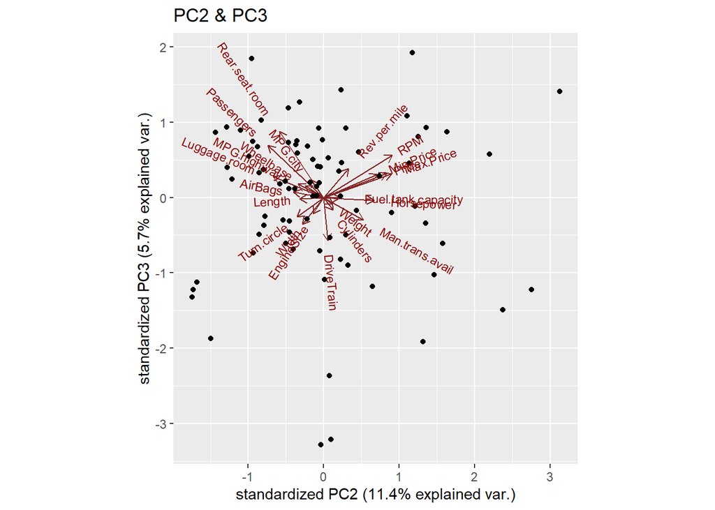

```r
# Biplot on PC3/PC4 grid
ggbiplot(dataset08_pca, choices = c(2,3)) +
  ggtitle('PC2 & PC3')
```

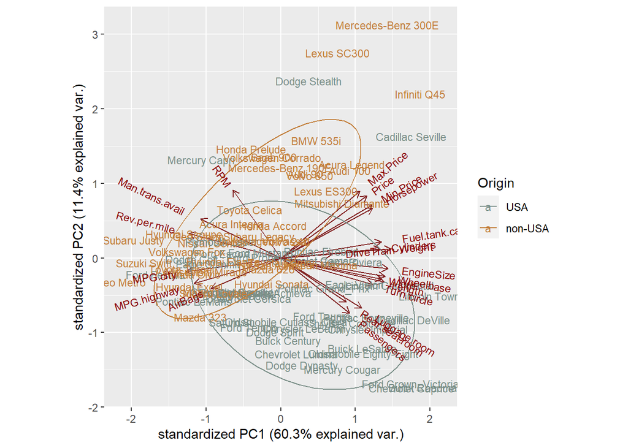

```r
ggbiplot(dataset08_pca, ellipse = TRUE, groups = origin, labels = make) +
  scale_color_manual(name = 'Origin', values = c(my_pal))
```

Non-USA cars are more efficient in terms of gas usage (but based purely on labels it’s rather for Japan cars - Subaru, Mazda, Suzuki). European cars (BMW, VW, Volvo) have worse parameters in terms of MPG. Also, non-USA cars (rather European) are more expensive.

Bi-plots grouped by origin AND type:

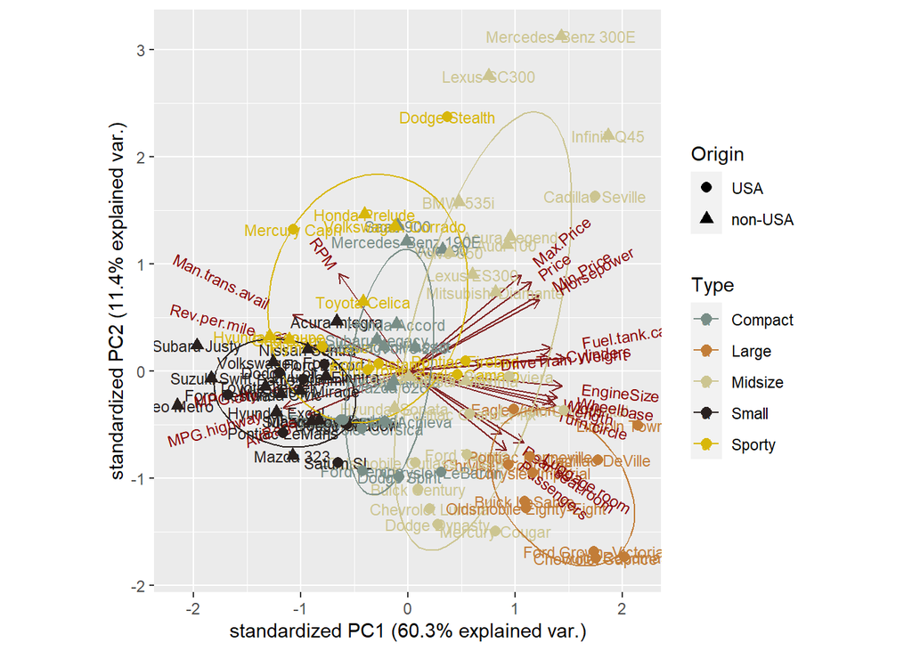

```r
ggbiplot(dataset08_pca, ellipse = TRUE, groups = type, labels = make) +
  geom_point(aes(color = type, shape = origin), size = 2.5) +
  scale_color_manual(name = 'Type', values = c(my_pal)) +
  scale_shape_manual(name = 'Origin', values = c(16,17))
```

**SUMMARY**: Midsize ans Sporty cars are the most diverse group (midsize in terms of price - cars from USA are cheaper than those non-USA originated).

The most clustered groups (with homogeneous parameters) are Small and Large cars.

All cars classified as Large are from USA.

There is no surprise that Small cars have the best parameters in terms of gas usage.

## **03. Data analysis - classification**

### **Exercise 09**

The Vehicle dataset from the mlbench package contains information (18 features, 846 observations) about silhouettes of cars (4 types).

- Construct classification models: LDA, QDA, 1NN & NB.
- Estimate the classification error for the constructed methods.
- Which of the constructed classifiers is recommendable for this data set? Justify your answer.
- Try to visualize the results in the space formed by the first two principal components.

##### **9.1 Load libraries, check & prepare data set**

1 factor (Class), 18 numeric variables, no missing values.

```r
library(mlbench)
library(class)  # for kNN
library(MASS)   # for LDA and QDA
library(klaR)   # for NaiveBayes() command

library(caret)  # for confusion matrix
library(lattice)

library(ipred)  # for errorest

# Data set
data(Vehicle)
dataset09 <- Vehicle
skimr::skim(dataset09)
```

Data summary

| Name | dataset09 |
| --- | --- |
| Number of rows | 846 |
| Number of columns | 19 |
| _______________________ |  |
| Column type frequency: |  |
| factor | 1 |
| numeric | 18 |
| ________________________ |  |
| Group variables | None |

**Variable type: factor**

| skim_variable | n_missing | complete_rate | ordered | n_unique | top_counts |
| --- | --- | --- | --- | --- | --- |
| Class | 0 | 1 | FALSE | 4 | bus: 218, saa: 217, ope: 212, van: 199 |

**Variable type: numeric**

| skim_variable | n_missing | complete_rate | mean | sd | p0 | p25 | p50 | p75 | p100 | hist |
| --- | --- | --- | --- | --- | --- | --- | --- | --- | --- | --- |
| Comp | 0 | 1 | 93.68 | 8.23 | 73 | 87.00 | 93.0 | 100 | 119 | ▂▇▆▅▁ |
| Circ | 0 | 1 | 44.86 | 6.17 | 33 | 40.00 | 44.0 | 49 | 59 | ▆▇▇▅▃ |
| D.Circ | 0 | 1 | 82.09 | 15.77 | 40 | 70.00 | 80.0 | 98 | 112 | ▁▃▇▃▆ |
| Rad.Ra | 0 | 1 | 168.94 | 33.47 | 104 | 141.00 | 167.0 | 195 | 333 | ▆▇▅▁▁ |
| Pr.Axis.Ra | 0 | 1 | 61.69 | 7.89 | 47 | 57.00 | 61.0 | 65 | 138 | ▇▂▁▁▁ |
| Max.L.Ra | 0 | 1 | 8.57 | 4.60 | 2 | 7.00 | 8.0 | 10 | 55 | ▇▁▁▁▁ |
| Scat.Ra | 0 | 1 | 168.84 | 33.24 | 112 | 146.25 | 157.0 | 198 | 265 | ▃▇▃▃▁ |
| Elong | 0 | 1 | 40.93 | 7.81 | 26 | 33.00 | 43.0 | 46 | 61 | ▆▃▇▃▁ |
| Pr.Axis.Rect | 0 | 1 | 20.58 | 2.59 | 17 | 19.00 | 20.0 | 23 | 29 | ▇▃▃▁▁ |
| Max.L.Rect | 0 | 1 | 148.00 | 14.52 | 118 | 137.00 | 146.0 | 159 | 188 | ▃▇▆▅▁ |
| Sc.Var.Maxis | 0 | 1 | 188.63 | 31.39 | 130 | 167.00 | 178.5 | 217 | 320 | ▆▇▆▁▁ |
| Sc.Var.maxis | 0 | 1 | 439.91 | 176.69 | 184 | 318.25 | 364.0 | 587 | 1018 | ▇▅▃▂▁ |
| Ra.Gyr | 0 | 1 | 174.70 | 32.55 | 109 | 149.00 | 173.0 | 198 | 268 | ▅▇▇▃▁ |
| Skew.Maxis | 0 | 1 | 72.46 | 7.49 | 59 | 67.00 | 71.5 | 75 | 135 | ▇▃▁▁▁ |
| Skew.maxis | 0 | 1 | 6.38 | 4.92 | 0 | 2.00 | 6.0 | 9 | 22 | ▇▆▃▂▁ |
| Kurt.maxis | 0 | 1 | 12.60 | 8.93 | 0 | 5.00 | 11.0 | 19 | 41 | ▇▆▃▂▁ |
| Kurt.Maxis | 0 | 1 | 188.93 | 6.16 | 176 | 184.00 | 188.0 | 193 | 206 | ▅▇▇▃▁ |
| Holl.Ra | 0 | 1 | 195.63 | 7.44 | 181 | 190.25 | 197.0 | 201 | 211 | ▅▃▇▆▂ |

Levels of “Class” variable: bus, opel, saab, van

```r
levels(dataset09$Class)
```

```
## [1] "bus"  "opel" "saab" "van"
```

Classes are distributed equally, enough data for QDA

```r
table(dataset09$Class)
```

```
##
##  bus opel saab  van
##  218  212  217  199
```

For 1NN method we need to divide data set to training and testing data sets: in order to create model, we need 2 **equally** sized data sets.

```r
# To get reproducible result
set.seed(123)

# Indices for training
n = nrow(dataset09)
train = sample(1:n, size = round(0.5*n), replace=FALSE)
train <- sort(train)
length(train)
```

```
## [1] 423
```

```r
# Indices for testing
idx = seq(n)
test <- idx[!idx %in% train]
length(test)
```

```
## [1] 423
```

##### **9.2 Models - 1NN, LDA, QDA, NB (normal and kernel)**

```r
                # train data - index + numeric variables
model_1NN <- knn(dataset09[train, 1:18],
                # test data - index + numeric variables
                dataset09[test, 1:18],
                # train data classes
                dataset09$Class[train],
                # number of neighbors
                k = 1)

model_LDA <- lda(Class ~ .,
                 data = dataset09)

model_QDA <- qda(Class ~ .,
                 data = dataset09)

model_nb_normal <- NaiveBayes(Class ~ .,
                              data = dataset09)

model_nb_kernel <- NaiveBayes(Class ~ .,
                              data = dataset09,
                              usekernel = TRUE)
```

##### **9.3 Prediction errors**

Prediction errors calculated based on **confusion matrix**: [prediction error] = [1 - accuracy]

Confusion matrix interpretation (based on results for 1NN method):

- ‘Bus’ class was predicted correctly 88 times. 12 times ‘bus’ was mistaken with ‘saab’, 5 times with ‘opel’ and 6 times with ‘van’.
- Most accurate prediction was for ‘van’ class - it was predicted correctly 84 times. ‘Van’ was mistaken 3 times with ‘bus’, 4 times with ‘opel’ and 2 times with ‘saab’.
- ‘Opel’ and ‘saab’ were confused most of the times.

```r
# 1NN
(nn_cm <- confusionMatrix(data = model_1NN, reference = dataset09$Class[test]))
```

```
## Confusion Matrix and Statistics
##
##           Reference
## Prediction bus opel saab van
##       bus   88    5   12   6
##       opel   5   46   52   1
##       saab  14   47   49   5
##       van    3    4    2  84
##
## Overall Statistics
##
##                Accuracy : 0.6312
##                  95% CI : (0.5833, 0.6773)
##     No Information Rate : 0.2719
##     P-Value [Acc > NIR] : <2e-16
##
##                   Kappa : 0.5074
##
##  Mcnemar's Test P-Value : 0.6104
##
## Statistics by Class:
##
##                      Class: bus Class: opel Class: saab Class: van
## Sensitivity              0.8000      0.4510      0.4261     0.8750
## Specificity              0.9265      0.8193      0.7857     0.9725
## Pos Pred Value           0.7928      0.4423      0.4261     0.9032
## Neg Pred Value           0.9295      0.8245      0.7857     0.9636
## Prevalence               0.2600      0.2411      0.2719     0.2270
## Detection Rate           0.2080      0.1087      0.1158     0.1986
## Detection Prevalence     0.2624      0.2459      0.2719     0.2199
## Balanced Accuracy        0.8633      0.6351      0.6059     0.9237
```

```r
# LDA
lda_cm <- confusionMatrix(data = predict(model_LDA, dataset09)$class, reference = dataset09$Class)

# QDA
qda_cm <- confusionMatrix(data = predict(model_QDA, dataset09)$class, reference = dataset09$Class)

# NB Normal
nbn_cm <- confusionMatrix(data = predict(model_nb_normal, dataset09)$class, reference = dataset09$Class)

# NB Kernel
nbk_cm <- confusionMatrix(data = predict(model_nb_kernel, dataset09)$class, reference = dataset09$Class)
```

Prediction errors calculated using **errorest** (2 methods: cross validation and bootstrap). For NB kernel we will use only bootstrap method, CV will return error.

```r
# Cross validation

# 1NN CV
mymod <- function(formula,
                  data,
                  l = 1) {
  ipredknn(formula = formula, data = data, k = l)

}
(nn_cv <- errorest(Class ~ .,
         data = dataset09,
         model = mymod,
         estimator = 'cv',
         predict = function(o, newdata) predict(o, newdata,  'class'),
         est.para = control.errorest(k = nrow(dataset09)),
         l = 1))
```

```
##
## Call:
## errorest.data.frame(formula = Class ~ ., data = dataset09, model = mymod,
##     predict = function(o, newdata) predict(o, newdata, "class"),
##     estimator = "cv", est.para = control.errorest(k = nrow(dataset09)),
##     l = 1)
##
##   846-fold cross-validation estimator of misclassification error
##
## Misclassification error:  0.3475
```

```r
# LDA CV
lda_cv <- errorest(Class ~ .,
         data = dataset09,
         model = lda,
         estimator = 'cv',
         predict = function(o, newdata) predict(o, newdata)$class,
         est.para = control.errorest(k = nrow(dataset09)))

# QDA CV
qda_cv <- errorest(Class ~ .,
         data = dataset09,
         model = qda,
         estimator = 'cv',
         predict = function(o, newdata) predict(o, newdata)$class,
         est.para = control.errorest(k = nrow(dataset09)))

# NB Normal CV
nbn_cv <- errorest(Class ~ .,
         data = dataset09,
         model = NaiveBayes,
         estimator = 'cv',
         predict = function(o, newdata) predict(o, newdata)$class,
         est.para = control.errorest(k = nrow(dataset09)),
         use.kerrnel = FALSE)


# Bootstrap

# 1NN bootstrap
(nn_boot <- errorest(Class ~ .,
         data = dataset09,
         model = ipredknn,
         estimator = 'boot',
         predict = function(o, newdata) predict(o, newdata, 'class'),
         est.para = control.errorest(nboot = 100),
         k = 1))
```

```
##
## Call:
## errorest.data.frame(formula = Class ~ ., data = dataset09, model = ipredknn,
##     predict = function(o, newdata) predict(o, newdata, "class"),
##     estimator = "boot", est.para = control.errorest(nboot = 100),
##     k = 1)
##
##   Bootstrap estimator of misclassification error
##   with 100 bootstrap replications
##
## Misclassification error:  0.3617
## Standard deviation: 0.0019
```

```r
# LDA bootstrap
lda_boot <- errorest(Class ~ .,
         data = dataset09,
         model = lda,
         estimator = 'boot',
         predict = function(o, newdata) predict(o, newdata)$class,
         est.para = control.errorest(nboot = 100))

# QDA bootstrap
qda_boot <- errorest(Class ~ .,
         data = dataset09,
         model = qda,
         estimator = 'boot',
         predict = function(o, newdata) predict(o, newdata)$class,
         est.para = control.errorest(nboot = 100))


# NB Normal bootstrap
nbn_boot <- errorest(Class ~ .,
         data = dataset09,
         model = NaiveBayes,
         estimator = 'boot',
         predict = function(o, newdata) predict(o, newdata)$class,
         est.para = control.errorest(nboot = 100),
         use.kerrnel = FALSE)

# NB Kernel bootstrap
nbk_boot <- errorest(Class ~ .,
         data = dataset09,
         model = NaiveBayes,
         estimator = 'boot',
         predict = function(o, newdata) predict(o, newdata)$class,
         est.para = control.errorest(nboot = 100),
         use.kerrnel = TRUE)
```

Summary of prediction errors:

| Error rate | 1NN | LDA | QDA | NB Normal | NB Kernel |
| --- | --- | --- | --- | --- | --- |
| **Confusion matrix** | 0.369 | 0.202 | 0.084 | 0.527 | 0.34 |
| **Errorest CV** | 0.348 | 0.221 | 0.144 | 0.541 | - |
| **Errorest bootstrap** | 0.362 | 0.224 | 0.162 | 0.548 | 0.552 |
| **Kappa** | 0.507 | 0.73 | 0.888 | 0.303 | 0.547 |

**SUMMARY**: Chosen model: QDA (lowest prediction error, kappa closest to 1). There is enough data in each class to correctly work with that method.

##### **9.4 Data visualization**

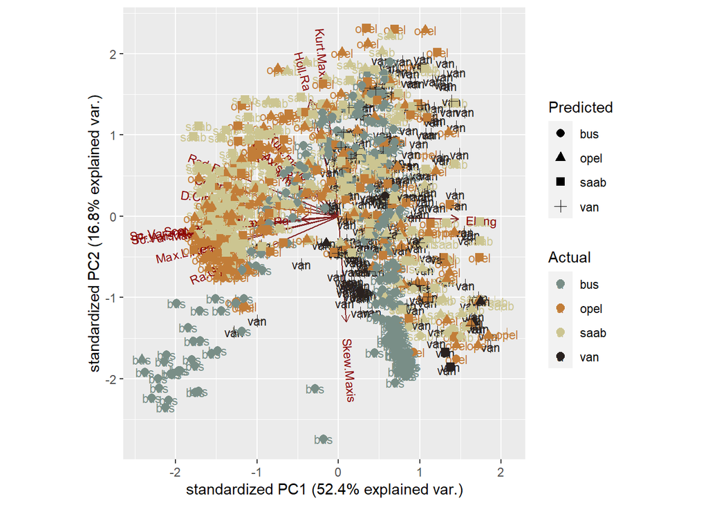

```r
# Two groups to compare data
actual <- c(dataset09$Class)
predicted <- c(predict(model_LDA, dataset09)$class)

# PCA
dataset09_pca <- prcomp(dataset09[,-19], scale. = TRUE)

# Biplot
ggbiplot(dataset09_pca, groups = actual, labels = dataset09$Class) +
  geom_point(aes(shape = predicted, colour = actual), size = 2.5) +
  labs(shape = 'Predicted', colour = 'Actual') +
  scale_color_manual(values = wes_palette('Moonrise2', n = 4))
```

## **04. Data analysis - cluster analysis**

### **Exercise 10**

For the mtcars data set, perform a hierarchical cluster analysis (mean binding method) and a non-hierarchical cluster analysis (k-means).

Draw a dendrogram.

How many clusters make sense? Determine the CH index and the silhouette factor.

How much clusters you can suggest based on them?

##### **10.1 Check & prepare data set**

11 numeric variables, no missing values.

```r
# Libraries
library(vegan)      # for cascadeKM() command
library(dendextend) # for fancy dendrogram
library(cluster)    # for silhouette() command

# Data set
dataset10 <- mtcars
skimr::skim(dataset10)
```

Data summary

| Name | dataset10 |
| --- | --- |
| Number of rows | 32 |
| Number of columns | 11 |
| _______________________ |  |
| Column type frequency: |  |
| numeric | 11 |
| ________________________ |  |
| Group variables | None |

**Variable type: numeric**

| skim_variable | n_missing | complete_rate | mean | sd | p0 | p25 | p50 | p75 | p100 | hist |
| --- | --- | --- | --- | --- | --- | --- | --- | --- | --- | --- |
| mpg | 0 | 1 | 20.09 | 6.03 | 10.40 | 15.43 | 19.20 | 22.80 | 33.90 | ▃▇▅▁▂ |
| cyl | 0 | 1 | 6.19 | 1.79 | 4.00 | 4.00 | 6.00 | 8.00 | 8.00 | ▆▁▃▁▇ |
| disp | 0 | 1 | 230.72 | 123.94 | 71.10 | 120.83 | 196.30 | 326.00 | 472.00 | ▇▃▃▃▂ |
| hp | 0 | 1 | 146.69 | 68.56 | 52.00 | 96.50 | 123.00 | 180.00 | 335.00 | ▇▇▆▃▁ |
| drat | 0 | 1 | 3.60 | 0.53 | 2.76 | 3.08 | 3.70 | 3.92 | 4.93 | ▇▃▇▅▁ |
| wt | 0 | 1 | 3.22 | 0.98 | 1.51 | 2.58 | 3.33 | 3.61 | 5.42 | ▃▃▇▁▂ |
| qsec | 0 | 1 | 17.85 | 1.79 | 14.50 | 16.89 | 17.71 | 18.90 | 22.90 | ▃▇▇▂▁ |
| vs | 0 | 1 | 0.44 | 0.50 | 0.00 | 0.00 | 0.00 | 1.00 | 1.00 | ▇▁▁▁▆ |
| am | 0 | 1 | 0.41 | 0.50 | 0.00 | 0.00 | 0.00 | 1.00 | 1.00 | ▇▁▁▁▆ |
| gear | 0 | 1 | 3.69 | 0.74 | 3.00 | 3.00 | 4.00 | 4.00 | 5.00 | ▇▁▆▁▂ |
| carb | 0 | 1 | 2.81 | 1.62 | 1.00 | 2.00 | 2.00 | 4.00 | 8.00 | ▇▂▅▁▁ |

High discrepancy in data set scale: data needs to be scaled.

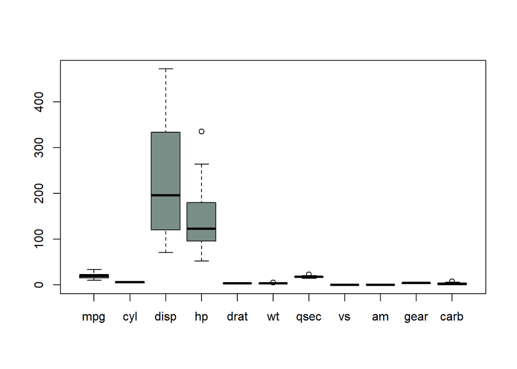

```r
boxplot(dataset10, col = moon[1])
```

```r
dataset10_sc <- as.data.frame(scale(dataset10))
```

##### **10.2 Number of clusters**

Based on Calinski criterion we should choose 10 clusters (the bigger value the better). While increasing max number of clusters in arguments, cascade model suggests more and more clusters as outcome (i.e with max set to 20, model proposes 20 clusters).

10 clusters seems a lot for just 32 different cars.

After scaling the data, we get highest CH index with 4 clusters. Final number of clusters to be confirmed based on dendrogram and silhouette factors (4 or 5 clusters).

```r
# For initial data set
                          # dataset, min # of cluster, max # of clusters
model_cascade <- cascadeKM(dataset10, 2, 10)
model_cascade$results
```

```
##             2 groups    3 groups    4 groups    5 groups    6 groups
## SSE      152564.4479 91343.40940 63319.83966 42849.39379 34380.93007
## calinski     92.5818    84.45753    82.55387    91.45128    89.08526
##             7 groups   8 groups   9 groups  10 groups
## SSE      26743.14367 19398.5044 12288.8951 10212.6539
## calinski    92.95908   106.7515   142.9672   146.7661
```

```r
plot(model_cascade, main = 'k-means for initial data set')

# For scaled data set
model_cascade_sc <- cascadeKM(dataset10_sc, 2, 10)
model_cascade_sc$results
```

```
##           2 groups  3 groups 4 groups 5 groups 6 groups 7 groups 8 groups
## SSE      179.08134 127.57236 86.81903 71.06127 58.72397 49.70647 42.01421
## calinski  27.12488  24.25839 27.32530 25.64106 24.99551 24.41781 24.39875
##          9 groups 10 groups
## SSE      35.20863  28.97627
## calinski 24.96974  26.32239
```

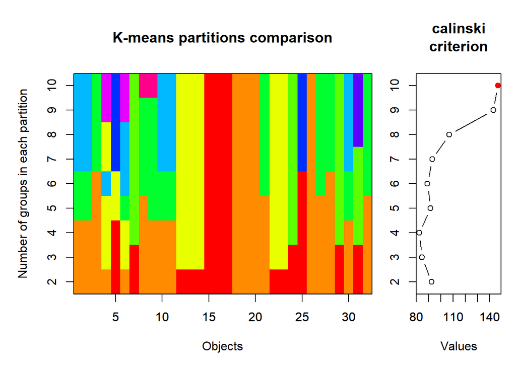

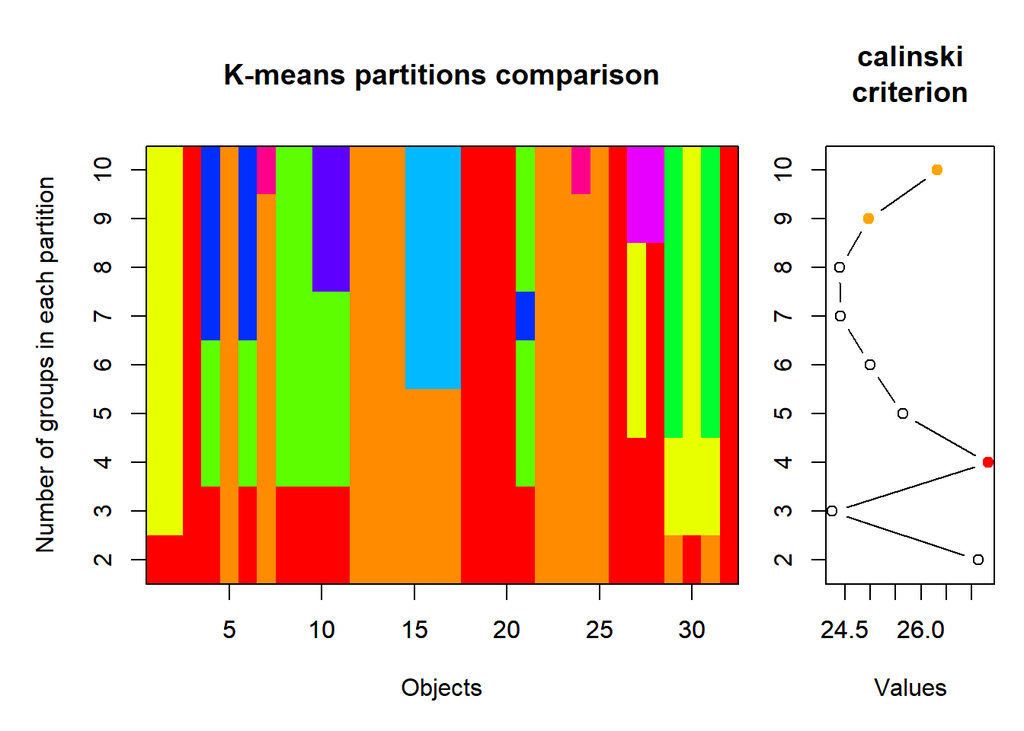

```r
plot(model_cascade_sc)
```

##### **10.3 Hierarchical clustering**

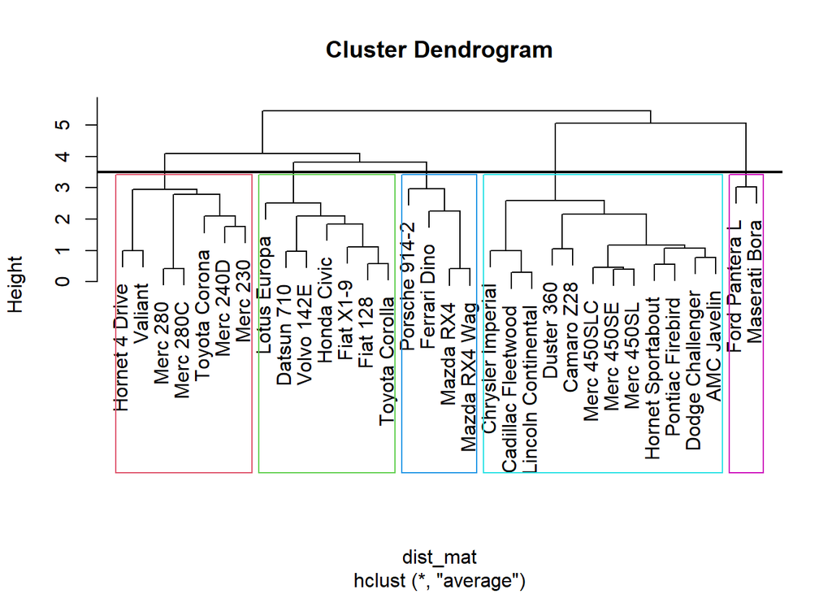

```r
# Distance matrix
dist_mat <- dist(dataset10_sc, method = 'euclidean')

# Hierarchical clustering & dendrogram
hclust_avg <- hclust(dist_mat, method = 'average')
plot(hclust_avg)
# Based on dendrogram >> 5 clusters

# Clusters marked on dendrogram
rect.hclust(hclust_avg , k = 5, border = 2:6)

# Height of the cut
abline(h = 3.5, col = 1, lwd = 2)
```

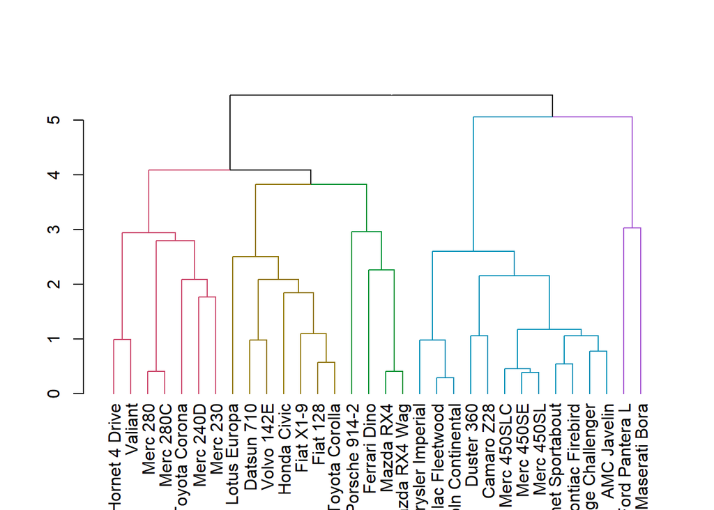

```r
# Dendrogram with colorful branches
avg_dend_obj <- as.dendrogram(hclust_avg)
avg_col_dend <- color_branches(avg_dend_obj, h = 3.5)
plot(avg_col_dend)
```

##### **10.4 k-means clustering**

For k = 4 silhouettes have different thickness (max for cluster 3), but all of them have similar height >> we aim for most unity in terms of shape.

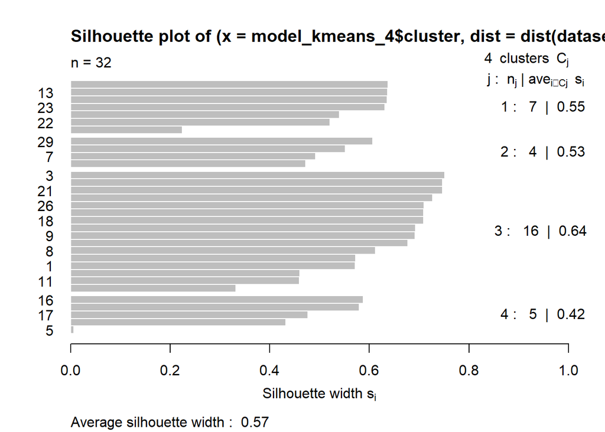

```r
# To get same results we need to set.seed()
set.seed(500)

# k-means model with 4 clusters
model_kmeans_4 <- kmeans(dataset10,
                       centers = 4,
                       nstart = 100)

sil_index_4 <- silhouette(model_kmeans_4$cluster,
                        dist = dist(dataset10,
                                    method = 'euclidean'))
plot(sil_index_4)
```

For k = 5 we get much better shape in terms of thickness, height remains similar.

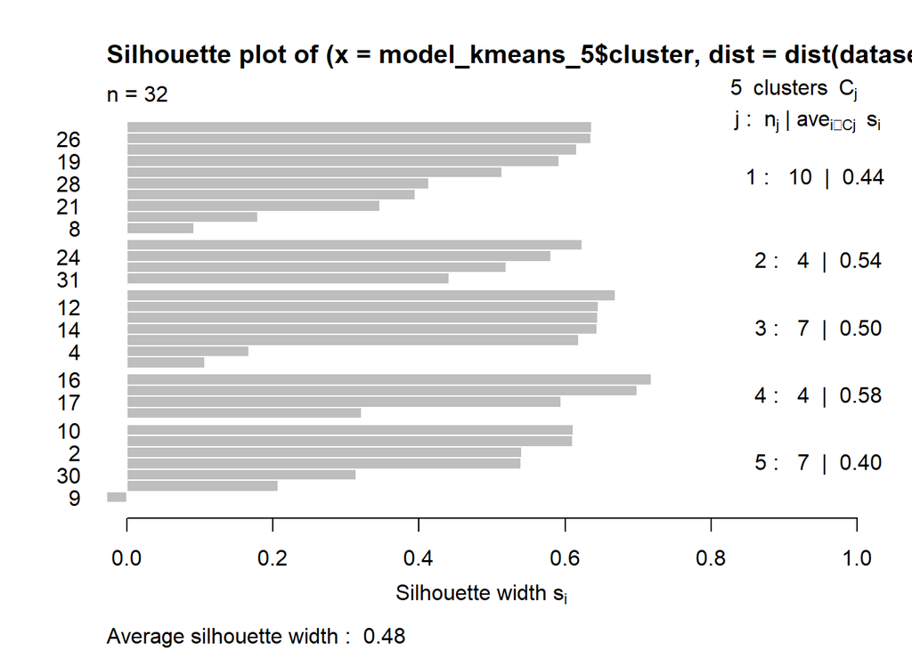

```r
# To get same results we need to set.seed()
set.seed(500)

# k-means model with 4 clusters
model_kmeans_5 <- kmeans(dataset10,
                       centers = 5,
                       nstart = 100)

sil_index_5 <- silhouette(model_kmeans_5$cluster,
                        dist = dist(dataset10,
                                    method = 'euclidean'))
plot(sil_index_5)
```

With more clusters silhouettes are getting more diverse, so we will keep 5 clusters.

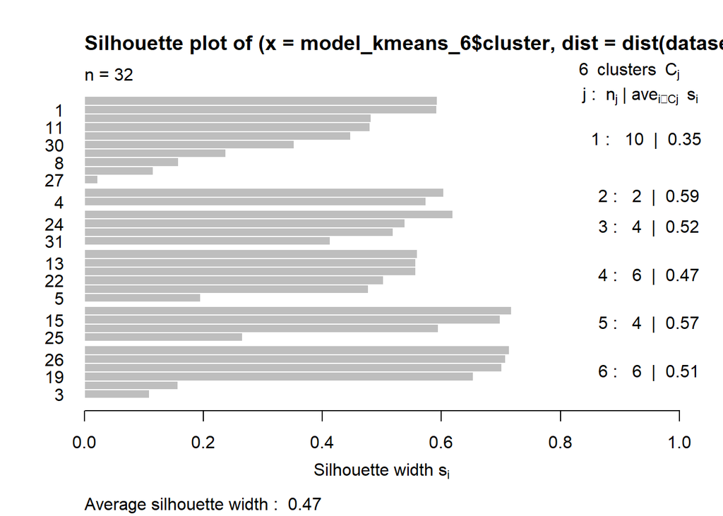

```r
# To get same results we need to set.seed()
set.seed(500)

# k-means model with 4 clusters
model_kmeans_6 <- kmeans(dataset10,
                       centers = 6,
                       nstart = 100)

sil_index_6 <- silhouette(model_kmeans_6$cluster,
                        dist = dist(dataset10,
                                    method = 'euclidean'))
plot(sil_index_6)
```

Each cluster mean s(i) is close to mean s(i) for whole data set:

```r
# mean s(i) for each cluster
summary(sil_index_5)
```

```
## Silhouette of 32 units in 5 clusters from silhouette.default(x = model_kmeans_5$cluster, dist = dist(dataset10, method = "euclidean")) :
##  Cluster sizes and average silhouette widths:
##        10         4         7         4         7
## 0.4421024 0.5413921 0.4995065 0.5832025 0.3994798
## Individual silhouette widths:
##     Min.  1st Qu.   Median     Mean  3rd Qu.     Max.
## -0.02815  0.34030  0.56076  0.47538  0.62651  0.71807
```

```r
# mean s(i)
mean(sil_index_5[, 3])
```

```
## [1] 0.4753846
```

##### **10.5 Visualize data with PCA**

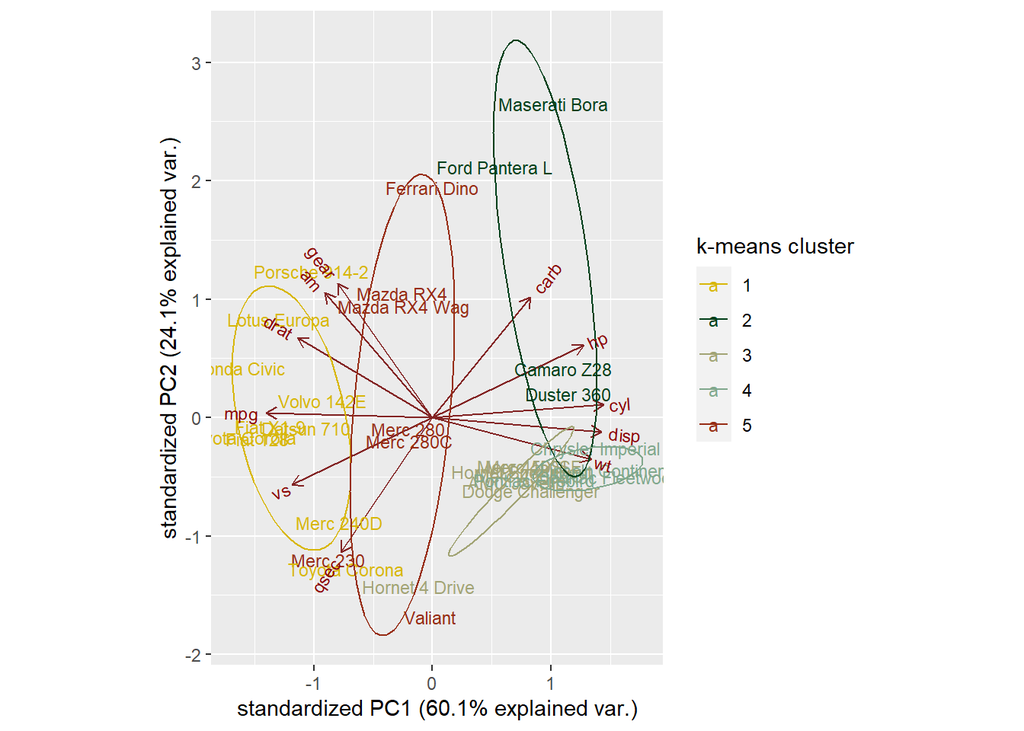

```r
# Add new column with k_means cluster
dataset10$Cluster <- as.factor(model_kmeans_5$cluster)

# Create PCA model (w/o cluster column)
dataset10_pca <- prcomp(dataset10[,-12], scale. = TRUE)

# Graph
ggbiplot(dataset10_pca, choices = c(1,2), ellipse=TRUE, groups = dataset10$Cluster, labels = rownames(dataset10)) +
  labs(colour = 'k-means cluster') +
  scale_color_manual(values= wes_palette('Cavalcanti1', n = 5))
```